# 00Introduction

## Introduction of the Course

## Object

- The object of this course is to collect students who are interesting in econometrics and programming, so that we all have a chance to discuss the application of Python in econometrics.

## Course Description

- There is no textbook for this course.
- Instead, we have slides and exercises for you.
- You could find enough material on the internet to help you.

## Course Description

- This will be a full English course. We will use English everywhere except conversation.
- There is no exam (or credit). Instead, we will have enough practice and homework to do.
- We will meet once a week, until the number of students are less than 3.
- You need to bring your laptop to the school of economics. This is a kind of cost to identify the students who are really interesting in this course.

## Course Prerequisite

- Mathematics:
  - Mathematical Analysis
  - Linear Algebra
  - Probability and Statistics

## Course Prerequisite

- Programming: You need to know some ideas of programming, any language is fine.
  - Variable, variable type
  - Function, parameters and return value
  - Loop and condition, for, while and if
  - Basic ideas of OOP (Object-Oriented Programming), class, attributes and methods

## Schedule

- We will first introduce the python essential, and then see its application in econometrics.
- You could find the necessary materials in the course website: bayeswhu.github.io
- You guys need to prepare to learn it by yourself and help each other.

## What is Python?

- Python is a general purpose programming language conceived in 1989 by Dutch programmer Guido van Rossum
- Python is free and open source
- Python is supported by a vast collection of standard and external software libraries
- Python has experienced rapid adoption in the last decade, and is now one of the most popular programming languages

## Common Uses

- Python is a general purpose language used in almost all application domains
  - communications
  - web development
  - CGI and graphical user interfaces
  - games
  - multimedia, data processing, security, etc., etc., etc.

## Common Uses

- Used extensively by Internet service and high tech companies such as
  - Google
  - Dropbox
  - Reddit
  - YouTube
  - Walt Disney Animation, etc., etc.
- Often used to teach computer science and programming

## Common Uses

- For reasons we will discuss, Python is particularly popular within the scientific community
  - academia, NASA, CERN, Wall St., etc., etc.

## Features

- A high level language suitable for rapid development
- Relatively small core language supported by many libraries
- A multiparadigm language, in that multiple programming styles are supported (procedural, object-oriented, functional, etc.)
- Interpreted rather than compiled

## Syntax and Design

- One nice feature of Python is its elegant syntax.
- Elegant code might sound superfluous but in fact it’s highly beneficial because it makes the syntax easy to read and easy to remember
- Closely related to elegant syntax is elegant design.
- Features like iterators, generators, decorators, list comprehensions, etc. make Python highly expressive, allowing you to get more done with less code.

## Scientific Programming

- Over the last decade, Python has become one of the core languages of scientific computing
- This section briefly showcases some examples of Python for scientific programming

## Numerical Programming

- Fundamental matrix and array processing capabilities are provided by the excellent NumPy library
- NumPy provides the basic array data type plus some simple processing operations

```python
import numpy as np                   # Load the library
a = np.linspace(-np.pi, np.pi, 100)  # Create array (even grid from -pi to pi)
b = np.cos(a)                        # Apply cosine to each element of a
c = np.ones(25)                      # An array of 25 ones
np.dot(c, c)                         # Compute inner product
```

## Numerical Programming

- The SciPy library is built on top of NumPy and provides additional functionality
- For example, let's calculate $\int_{-2}^2\phi(z)dz$ where $\phi$ is the standard normal density

```python
from scipy.stats import norm
from scipy.integrate import quad
phi = norm()
value, error = quad(phi.pdf, -2, 2)  # Integrate using Gaussian quadrature
value
```

## Numerical Programming

- SciPy includes many of the standard routines used in
  - linear algebra
  - integration
  - interpolation
  - optimization
  - distributions and random number generation
  - signal processing, etc., etc.

## Graphics

- The most popular and comprehensive Python library for creating figures and graphs is Matplotlib
  - Plots, histograms, contour images, 3D, bar charts, etc., etc.
  - Output in many formats (PDF, PNG, EPS, etc.)
  - LaTeX integration

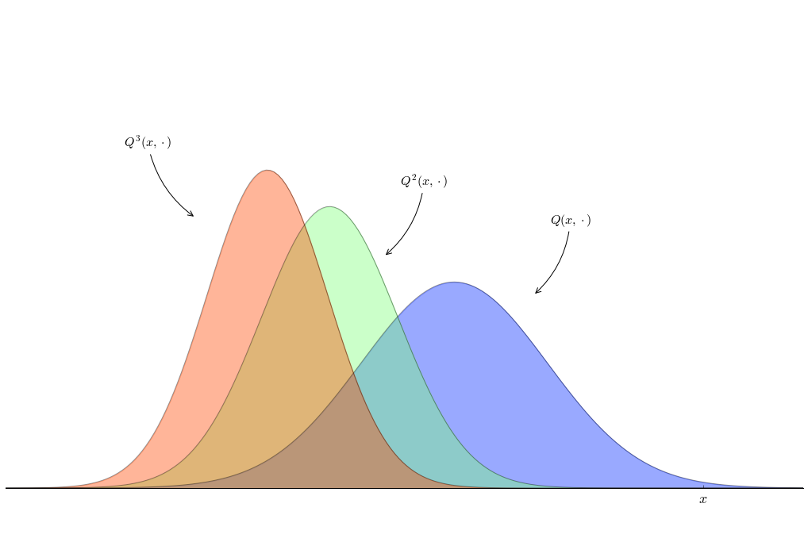

```python
%matplotlib inline
from matplotlib import rcParams
rcParams['figure.figsize'] = (18, 12)
import matplotlib.pyplot as plt
import numpy as np
from scipy.stats import norm
from matplotlib import cm

xmin, xmax = -4, 12
x = 10
alpha = 0.5

m, v = x, 10

xgrid = np.linspace(xmin, xmax, 200)

fig, ax = plt.subplots()

ax.spines['right'].set_color('none')
ax.spines['top'].set_color('none')
ax.spines['left'].set_color('none')
ax.xaxis.set_ticks_position('bottom')
ax.spines['bottom'].set_position(('data', 0))

ax.set_ylim(-0.05, 0.5)
ax.set_xticks((x,))
ax.set_xticklabels((r'$x$',), fontsize=18)
ax.set_yticks(())

K = 3
for i in range(K):
    m = alpha * m
    v = alpha * alpha * v + 1
    f = norm(loc=m, scale=np.sqrt(v))
    k = (i + 0.5) / K
    ax.plot(xgrid, f.pdf(xgrid), lw=1, color='black', alpha=0.4)
    ax.fill_between(xgrid, 0 * xgrid, f.pdf(xgrid), color=cm.jet(k), alpha=0.4)

ax.annotate(r'$Q(x,\cdot)$', xy=(6.6, 0.2),  xycoords='data',
            xytext=(20, 90), textcoords='offset points', fontsize=16,
            arrowprops=dict(arrowstyle="->", connectionstyle="arc3,rad=-0.2"))
ax.annotate(r'$Q^2(x,\cdot)$', xy=(3.6, 0.24),  xycoords='data',
            xytext=(20, 90), textcoords='offset points', fontsize=16,
            arrowprops=dict(arrowstyle="->", connectionstyle="arc3,rad=-0.2"))
ax.annotate(r'$Q^3(x,\cdot)$', xy=(-0.2, 0.28),  xycoords='data',
            xytext=(-90, 90), textcoords='offset points', fontsize=16,
            arrowprops=dict(arrowstyle="->", connectionstyle="arc3,rad=0.2"))
plt.show()
```

## Other Examples

- One day, I was asked to plot the figure for $\sin(x^2+y^2)=\cos(xy)$
- I think it is very easy: for any x, solve y and plot the figure, and then I find it is very difficult to do so, since this is not a one-to-one function.
- What should I do?

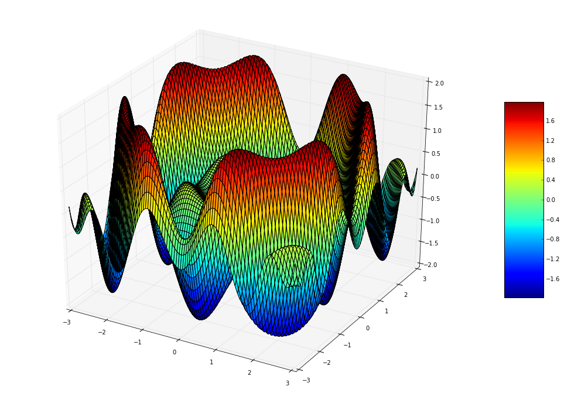

```python
%matplotlib inline
from matplotlib import rcParams
rcParams['figure.figsize'] = (18, 12)
import matplotlib.pyplot as plt
import numpy as np
from mpl_toolkits.mplot3d import Axes3D
from matplotlib import cm

fig = plt.figure()
ax = fig.gca(projection='3d')
x=np.linspace(-3,3,1000)
y=np.linspace(-3,3,1000)
X,Y=np.meshgrid(x,y)
Z=np.sin(X**2+Y**2)-np.cos(X*Y)
surf=ax.plot_surface(X,Y,Z,cmap=cm.jet)
fig.colorbar(surf, shrink=0.5, aspect=5)
plt.show()
```

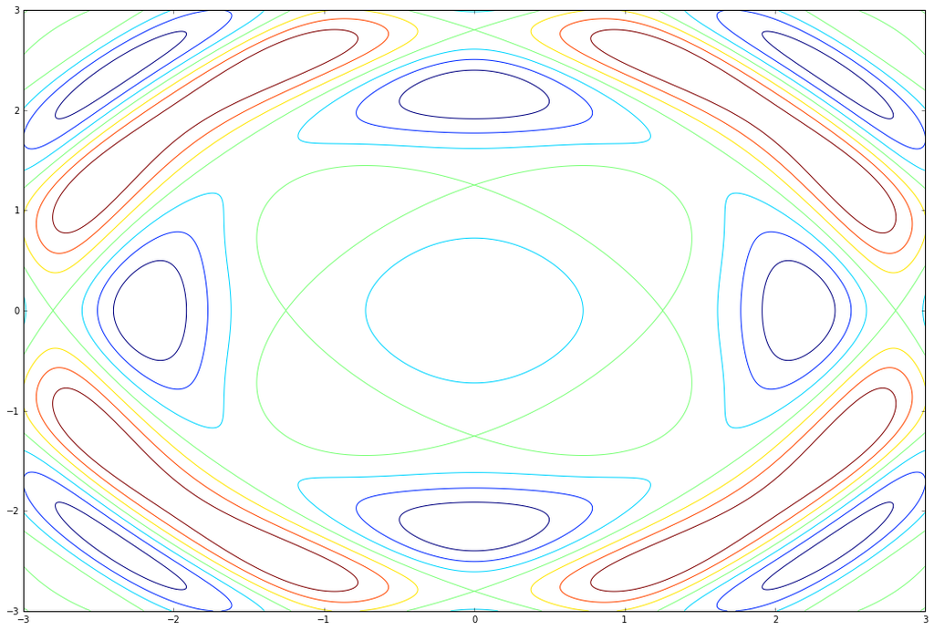

```python
%matplotlib inline
from matplotlib import rcParams
rcParams['figure.figsize'] = (18, 12)
import matplotlib.pyplot as plt
import numpy as np
from matplotlib import cm

fig,ax=plt.subplots()
x=np.linspace(-3,3,1000)
y=np.linspace(-3,3,1000)
X,Y=np.meshgrid(x,y)
Z=np.sin(X**2+Y**2)-np.cos(X*Y)
cnt = plt.contour(X,Y,Z, cmap=cm.jet)
plt.show()
```

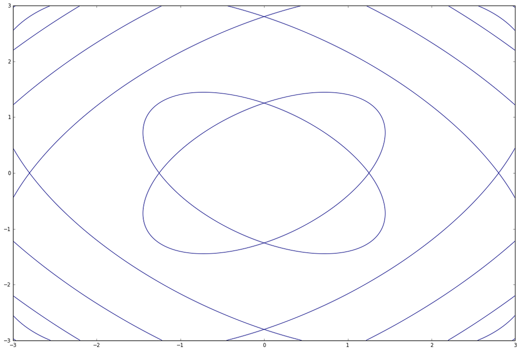

```python
%matplotlib inline
from matplotlib import rcParams
rcParams['figure.figsize'] = (18, 12)
import matplotlib.pyplot as plt
import numpy as np
from matplotlib import cm

fig,ax=plt.subplots()
x=np.linspace(-3,3,1000)
y=np.linspace(-3,3,1000)
X,Y=np.meshgrid(x,y)
Z=np.sin(X**2+Y**2)-np.cos(X*Y)
cnt = plt.contour(X,Y,Z,[0],cmap=cm.jet)
plt.show()
```

## Symbolic Algebra

- Sometimes it’s useful to be able to manipulate symbolic expressions in the spirit of Mathematica/Maple
- The SymPy library provides this functionality from within the Python shell

## Symbolic Algebra

```python
from sympy import Symbol
x, y = Symbol('x'), Symbol('y')  # Treat 'x' and 'y' as algebraic symbols
x + x + x + y
```

```python
expression = (x + y)**2
expression.expand()
```

```python
from sympy import solve
solve(x**2 + x + 2)
```

## Symbolic Algebra

```python
from sympy import limit, sin, diff
limit(1 / x, x, 0)
```

```python
limit(sin(x) / x, x, 0)
```

```python
diff(sin(x), x)
```

## Symbolic Algebra

- In fact, the previous problem could also be solved by SymPy.

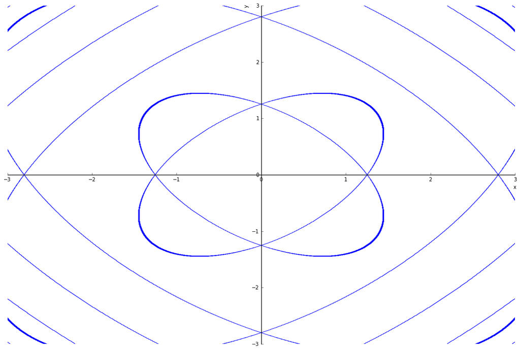

```
<sympy.plotting.plot.Plot at 0x1187e2898>
```

```python
%matplotlib inline
from matplotlib import rcParams
rcParams['figure.figsize'] = (18, 12)
from sympy import plot_implicit, cos, sin, symbols, Eq
x, y = symbols('x y')
plot_implicit(Eq(sin(x**2+y**2),cos(x*y)),(x, -3, 3), (y, -3, 3))
```

## Statistics

- Python’s data manipulation and statistics libraries have improved rapidly over the last few years
- One of the most popular libraries for working with data is pandas

```python
import pandas as pd
import scipy as sp
data = sp.randn(5, 2)  # Create 5x2 matrix of random numbers for toy example
dates = pd.date_range('28/12/2010', periods=5)
df = pd.DataFrame(data, columns=('price', 'weight'), index=dates)
print(df)
```

```python
df.mean()
```